# 빅콘데스트 챌린지리그 : 대출 연체,상환 예측하기

장은아 (dmsdk2121@gmail.com)

2017.10.13

## Introduction.

### 2017 빅콘데스트 챌린지리그 : 대출 연체,상환 예측하기

> 보험, 통신, 신용평가사 (개인정보 비식별)결합데이터를 활용한 대출상환 예측 알고리즘 개발

##### 실제 기업 (한화생명/SKT/SCI) Data 기반의 데이터

- 한화생명 : 직업 / 소득 / 배우자직업 / 신용등급 / 한화생명 신용대출정보 / 보험 정보 등 36개
- SKT : 통화시간 / 멤버쉽 등급 / 가입년월 / 정지 일수 / 연체금액 등 15개
- SCI : 대출 건수 / 대출 총 금액 / 대출계좌 유지 기간 / 보증 건수 / 보증 금액 등 14개

전체변수 총 69 개 , 관측치 102,252개

TARGET의 반응비율(연체한 비율)이 4%대로 매우 낮음

평가지표 : 예측값의 F1 score

## # 목차

### 1. 데이터 로드하기

#### 1) 데이터 구조 파악하기

### 2. 데이터 전처리 (check for null and missing values)

#### 1) OCCP_NAME_G 직업 살펴보기

#### 2) AGE 데이터 살펴보기

#### 3) SEX 성별 데이터 살펴보기

#### 4) LAST_CHLD_AGE 막내자녀나이 데이터 살펴보기

#### 5) PAYM_METD 납부방법 데이터 살펴보기

### 3. 데이터 나누기 (train, test)

### 4. 변수 중요도 파악하기

#### 1) 병렬처리를 위한 Parallel패키지 사용하기

#### 2) nearZeroVar() 함수를 사용해 분산이 0에 가까운 변수를 찾기

#### 3) 랜덤포레스트 모델을 사용해 중요한 변수 찾기

### 5. 랜덤포레스트 모델 사용하기

#### 1) 모델 적합, 튜닝하기

#### 2) 튜닝한 모델로 예측하기

#### 3) 예측한 결과 분석하기

### 6. SVM 모델 사용하기

#### 1) 모델 적용 전에 데이터 스케일링, 센터링 작업

#### 2) 모델 적합, 튜닝하기

#### 3) 튜닝한 모델로 예측하기

#### 4) 예측한 결과 분석하기

### 7. 최종예측

```r
# 패키지 로드
library(dplyr)
library(ggplot2)
library(ISLR)
library(MASS)
library(glmnet)
library(randomForest)
library(gbm)
library(rpart)
library(boot)
library(rpart)
library(caret)
```

### 1. 데이터 로드하기

```r
setwd("/Users/jang-eun-a/challenge_data")
options("scipen" = 100)
train.data <- read.csv("Data_set.csv", header = TRUE)
test.data <- read.csv("Test_set.csv", header = TRUE)
full.data <- rbind(train.data, test.data)
dim(full.data)
```

```
[1] 102252     69
```

#### 1) 데이터 구조 살펴보기

```r
# glimpse(full.data)
# TARGET , CUST_ID , LAST_CHLD_AGE factor형으로 바꾸기
full.data$TARGET <- as.factor(full.data$TARGET)
full.data$CUST_ID <- as.factor(full.data$CUST_ID)
full.data$LAST_CHLD_AGE <- as.factor(full.data$LAST_CHLD_AGE)
glimpse(full.data)
```

```
Observations: 102,252
Variables: 69
$ CUST_ID           <fctr> 1, 2, 3, 4, 5, 6, 7, 8, 9, 10, 11, 12, 13,...
$ TARGET            <fctr> 0, 0, 0, 1, 0, 0, 0, 0, 0, 0, 1, 0, 0, 0, ...
$ BNK_LNIF_CNT      <int> 1, 1, 0, 0, 4, 1, 0, 1, 2, 0, 0, 0, 1, 2, 3...
$ CPT_LNIF_CNT      <int> 0, 0, 1, 2, 0, 0, 1, 0, 0, 1, 3, 1, 0, 0, 1...
$ SPART_LNIF_CNT    <int> 0, 0, 3, 4, 0, 1, 2, 0, 0, 1, 5, 2, 0, 0, 1...
$ ECT_LNIF_CNT      <int> 0, 0, 2, 2, 0, 1, 1, 0, 0, 0, 2, 1, 0, 0, 0...
$ TOT_LNIF_AMT      <int> 9001, 24001, 15001, 6001, 21001, 141001, 12...
$ TOT_CLIF_AMT      <int> 9001, 0, 9001, 3001, 15001, 27001, 3001, 30...
$ BNK_LNIF_AMT      <int> 9001, 24001, 0, 0, 21001, 111001, 0, 3001, ...
$ CPT_LNIF_AMT      <int> 0, 0, 3001, 3001, 0, 0, 9001, 0, 0, 9001, 1...
$ CRDT_OCCR_MDIF    <int> 1, 0, 1, 1, 1, 1, 121, 1, 37, 1, 1, 49, 13,...
$ SPTCT_OCCR_MDIF   <int> 0, 0, 25, 25, 0, 1, 121, 0, 0, 1, 25, 49, 0...
$ CRDT_CARD_CNT     <int> 2, 2, 4, 4, 1, 4, 2, 2, 5, 3, 4, 6, 0, 4, 3...
```

[output cut: 56 more lines]

```r
summary(full.data)
```

```
    CUST_ID        TARGET       BNK_LNIF_CNT     CPT_LNIF_CNT
 1      :     1   0   :95946   Min.   :0.0000   Min.   :0.0000
 2      :     1   1   : 4287   1st Qu.:0.0000   1st Qu.:0.0000
 3      :     1   NA's: 2019   Median :1.0000   Median :0.0000
 4      :     1                Mean   :0.8401   Mean   :0.5013
 5      :     1                3rd Qu.:1.0000   3rd Qu.:1.0000
 6      :     1                Max.   :5.0000   Max.   :5.0000
 (Other):102246
 SPART_LNIF_CNT    ECT_LNIF_CNT    TOT_LNIF_AMT     TOT_CLIF_AMT
 Min.   :0.0000   Min.   :0.000   Min.   :     1   Min.   :     0
 1st Qu.:0.0000   1st Qu.:0.000   1st Qu.: 12001   1st Qu.:     0
 Median :1.0000   Median :0.000   Median : 39001   Median :  9001
 Mean   :0.9533   Mean   :0.478   Mean   : 84028   Mean   : 33233
 3rd Qu.:1.0000   3rd Qu.:1.000   3rd Qu.:105001   3rd Qu.: 27001
 Max.   :7.0000   Max.   :6.000   Max.   :994001   Max.   :994001

  BNK_LNIF_AMT     CPT_LNIF_AMT    CRDT_OCCR_MDIF   SPTCT_OCCR_MDIF
 Min.   :     0   Min.   :     0   Min.   :  0.00   Min.   :  0.00
 1st Qu.:     0   1st Qu.:     0   1st Qu.:  0.00   1st Qu.:  0.00
 Median :  9001   Median :     0   Median :  1.00   Median :  0.00
 Mean   : 51609   Mean   :  4189   Mean   : 18.08   Mean   : 13.99
 3rd Qu.: 63001   3rd Qu.:  3001   3rd Qu.: 25.00   3rd Qu.: 13.00
 Max.   :944001   Max.   :301001   Max.   :121.00   Max.   :121.00

 CRDT_CARD_CNT    CTCD_OCCR_MDIF    CB_GUIF_CNT        CB_GUIF_AMT
 Min.   : 0.000   Min.   :  0.00   Min.   : 0.00000   Min.   :     0
 1st Qu.: 2.000   1st Qu.: 61.00   1st Qu.: 0.00000   1st Qu.:     0
 Median : 3.000   Median :121.00   Median : 0.00000   Median :     0
 Mean   : 3.092   Mean   : 91.01   Mean   : 0.09626   Mean   :  9168
 3rd Qu.: 4.000   3rd Qu.:121.00   3rd Qu.: 0.00000   3rd Qu.:     0
 Max.   :11.000   Max.   :121.00   Max.   :10.00000   Max.   :980001

         OCCP_NAME_G    CUST_JOB_INCM   HSHD_INFR_INCM  ACTL_FMLY_NUM
 주부          :28137   Min.   :    0   Min.   :    0   Min.   :1.000
 사무직        :16924   1st Qu.:    0   1st Qu.: 4800   1st Qu.:2.000
 2차산업 종사자: 9816   Median : 3600   Median : 6600   Median :3.000
 자영업        : 9663   Mean   : 2788   Mean   : 6922   Mean   :2.758
 3차산업 종사자: 8421   3rd Qu.: 4700   3rd Qu.: 9200   3rd Qu.:4.000
 공무원        : 5184   Max.   :10000   Max.   :20000   Max.   :8.000
 (Other)       :24107
```

[output cut: 88 more lines]

```
  TEL_CNTT_QTR    NUM_DAY_SUSP     CRMM_OVDU_AMT     TLFE_UNPD_CNT
 Min.   :19934   Min.   :   0.00   Min.   :      0   Min.   :0.000000
 1st Qu.:20113   1st Qu.:   0.00   1st Qu.:      0   1st Qu.:0.000000
 Median :20132   Median :   0.00   Median :      0   Median :0.000000
 Mean   :20122   Mean   :  17.11   Mean   :  11028   Mean   :0.003697
 3rd Qu.:20143   3rd Qu.:   0.00   3rd Qu.:      0   3rd Qu.:0.000000
 Max.   :20162   Max.   :2700.00   Max.   :1200000   Max.   :2.000000

 LT1Y_MXOD_AMT     PAYM_METD LINE_STUS    MOBL_PRIN
 Min.   :      0    : 2878   S:  1949   Min.   :      0
 1st Qu.:      0   G: 4625   U:100303   1st Qu.:      0
 Median :      0   K:33027              Median : 100000
 Mean   :  19157   O:58076              Mean   : 190114
 3rd Qu.:      0   R: 3646              3rd Qu.: 320000
 Max.   :1600000                        Max.   :1100000
```

### 2. 데이터 전처리 (NA값 채우기)

#### 1) OCCP_NAME_G 직업 살펴보기

```r
summary(full.data$OCCP_NAME_G)
```

```
              *  1차산업 종사자  2차산업 종사자  3차산업 종사자
           1204            1205            9816            8421
  고소득 전문직          공무원  기업/단체 임원            기타
           1247            5184            1064            1710
    단순 노무직     단순 사무직          사무직 예체능계 종사자
            840            4186           16924             954
         운전직          자영업          전문직            주부
           2172            9663            5142           28137
           학생            NULL
           3912             471
```

summary 결과,

- 결측치(NA값)가 “NULL”로 되어있는 것을 볼 수 있다.
- 알 수 없는 경우와 직업이 없는 경우 등이 * 로 비식별 처리되었다.

분포를 보기 위해 시각화해보면,

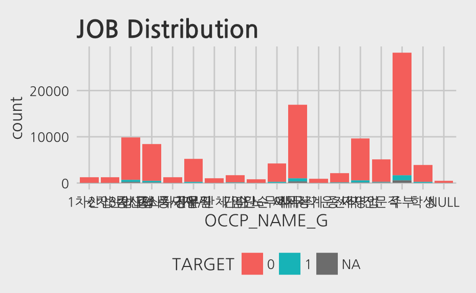

```r
full.data %>%
  ggplot(aes(OCCP_NAME_G,fill=TARGET)) +
  geom_bar() +
  ggtitle("JOB Distribution")
```

*로 비식별된 데이터는 비식별의 특수성을 고려하여 하나의 범주로 처리한다.

그리고 NULL 데이터는 어떻게 처리해야 할까? 우선 직업별 연체자의 비율을 살펴보자.

```r
# 직업별 연체자의 비율
# NULL이면서 TARGET이 1(연체한)인 사람의 비율 : 0.05818966
nrow(subset(train.data, train.data$OCCP_NAME_G == "NULL" & train.data$TARGET == 1))/sum(train.data$OCCP_NAME_G == "NULL")
```

```
[1] 0.05818966
```

```r
# 주부이면서 TARGET이 1(연체한)인 사람의 비율 : 0.04106657
nrow(subset(train.data, train.data$OCCP_NAME_G == "주부" & train.data$TARGET == 1))/sum(train.data$OCCP_NAME_G == "주부")
```

```
[1] 0.04106657
```

```r
# 사무직이면서 TARGET이 1(연체한)인 사람의 비율 : 0.04191545
nrow(subset(train.data, train.data$OCCP_NAME_G == "사무직" & train.data$TARGET == 1))/sum(train.data$OCCP_NAME_G == "사무직")
```

```
[1] 0.04191545
```

```r
# 3차산업 종사자이면서 TARGET이 1(연체한)인 사람의 비율 : 0.04386707
nrow(subset(train.data, train.data$OCCP_NAME_G == "3차산업 종사자" & train.data$TARGET == 1))/sum(train.data$OCCP_NAME_G == "3차산업 종사자")
```

```
[1] 0.04386707
```

```r
# 전문직이면서 TARGET이 1(연체한)인 사람의 비율 : 0.04322824
nrow(subset(train.data, train.data$OCCP_NAME_G == "전문직" & train.data$TARGET == 1))/sum(train.data$OCCP_NAME_G == "전문직")
```

```
[1] 0.04322824
```

```r
# 공무원이면서 TARGET이 1(연체한)인 사람의 비율 : 0.03555294
nrow(subset(train.data, train.data$OCCP_NAME_G == "공무원" & train.data$TARGET == 1))/sum(train.data$OCCP_NAME_G == "공무원")
```

```
[1] 0.03555294
```

다음 결과에서 NULL인 경우의 연체자의 비율이 다른 직업군보다 연체율이 높다.

그러므로 NULL인 데이터를 하나의 범주로 처리한다.

#### 2) AGE 데이터 살펴보기

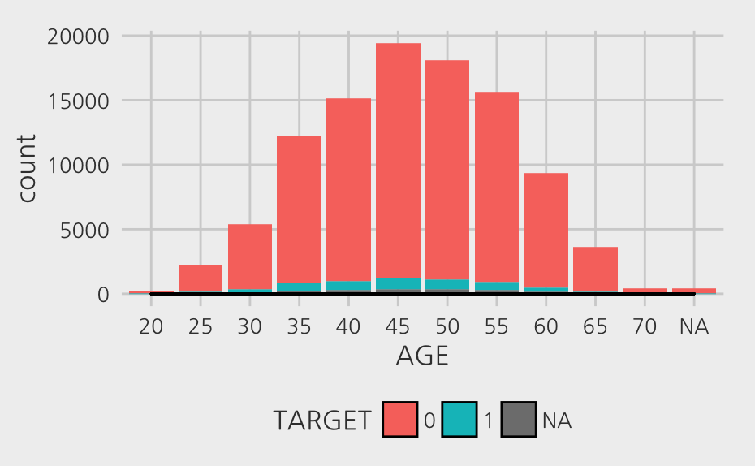

```r
# *로 비식별된 데이터를 NA로 대체한다.
full.data$AGE[full.data$AGE == "*"] <- NA
# 그래프로 분포 시각화
full.data %>%
  ggplot(aes(AGE, fill=TARGET)) +
  geom_bar() +
  geom_density(alpha=.5)
```

```r
summary(full.data$AGE)
```

```
    *    20    25    30    35    40    45    50    55    60    65    70
    0   245  2254  5360 12217 15116 19426 18116 15643  9381  3652   408
 NA's
  434
```

AGE데이터의 결측값은 434개이며, 전체 데이터의 약 0.4%정도이다. 통계적으로 영향을 미치는 정도가 적지만 삭제하기엔 손실되는 데이터가 아깝다.

분류모델인 의사결정나무로 예측하여 대체하자 의사결정나무는 계산 비용이 낮아 대규모의 데이터 셋에서도 비교적 빠르게 연산이 가능하다.

#### 결측치처리

```r
##### Decision Tree #####
col.pred <- c("HSHD_INFR_INCM","FMLY_GDINS_MNPREM","TOT_PREM","AUTR_FAIL_MCNT", "AGE",
               "FMLY_PLPY_CNT","CPT_LNIF_CNT","ECT_LNIF_CNT","TOT_LNIF_AMT","CRDT_OCCR_MDIF",
               "CRDT_CARD_CNT","OCCP_NAME_G","SEX","PAYM_METD","MATE_OCCP_NAME_G")
# train에 쓸 데이터프레임을 만든다.
df.pred <- full.data[!is.na(full.data$AGE), col.pred]
# Decision Tree model
AGE.rpart <- rpart(as.factor(AGE) ~ .,
                           data = df.pred,
                           method = "class",
                           na.action=na.omit)
# 결측치 채우기
full.data$AGE[is.na(full.data$AGE)] <- predict(AGE.rpart,
                           full.data[is.na(full.data$AGE),col.pred],
                           type="class")
summary(full.data$AGE)
```

```
    *    20    25    30    35    40    45    50    55    60    65    70
    0   245  2254  5360 12359 15116 19426 18408 15643  9381  3652   408
```

```r
# 빈 factor 레벨 지우기
full.data$AGE <- as.character(full.data$AGE)
full.data$AGE <- as.factor(full.data$AGE)
```

#### 3) SEX 성별 데이터 살펴보기

```r
full.data$SEX[full.data$SEX == "*"] <- NA
summary(full.data$SEX)
```

```
    *     1     2  NA's
    0 46218 55600   434
```

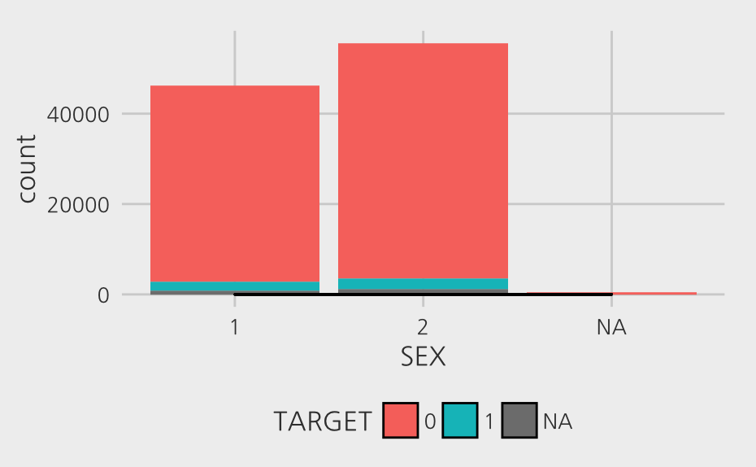

```r
full.data %>%
  ggplot(aes(SEX, fill=TARGET)) +
  geom_bar() +
  geom_density(alpha=.5)
```

2(여성)데이터가 더 많으며,

SEX(성별)데이터의 결측치는 434개로 전체 데이터 중 0.4% 정도이다.

마찬가지로 의사결정나무로 예측하여 결측값 채우기

#### 결측치처리

```r
##### Decision Tree #####
full.data$SEX[full.data$SEX == "NULL"] <- NA
col.pred3 <- c("HSHD_INFR_INCM","FMLY_GDINS_MNPREM","TOT_PREM","AUTR_FAIL_MCNT", "AGE",
               "FMLY_PLPY_CNT","CPT_LNIF_CNT","SPART_LNIF_CNT","ECT_LNIF_CNT","TOT_LNIF_AMT",
               "CRDT_OCCR_MDIF","SPTCT_OCCR_MDIF","CRDT_CARD_CNT","OCCP_NAME_G","SEX",
               "MON_TLFE_AMT","TEL_CNTT_QTR", "TEL_MBSP_GRAD" ,"PAYM_METD","MATE_OCCP_NAME_G"
               )
df.pred3 <- full.data[!is.na(full.data$SEX), col.pred3]
SEX.rpart <- rpart(as.factor(SEX) ~ .,
                           data = df.pred3,
                           method = "class",
                           na.action=na.omit)
full.data$SEX[is.na(full.data$SEX)] <- predict(SEX.rpart,
                           full.data[is.na(full.data$SEX),col.pred3],
                           type="class")
summary(full.data$SEX)
```

```
    *     1     2
    0 46308 55944
```

```r
# 빈 factor레벨 지우기
full.data$SEX <- as.character(full.data$SEX)
full.data$SEX <- as.factor(full.data$SEX)
#잘 들어갔는지 확인
summary(full.data$SEX)
```

```
    1     2
46308 55944
```

#### 4) LAST_CHLD_AGE 막내자녀나이 데이터 살펴보기

```r
summary(full.data$LAST_CHLD_AGE)
```

```
    0    14    19    24    29    34    39     4    44    49    54    59
51146  5910  9834 10992  8097  5702  4371   552  1248   335    46    17
   60     9  NULL
   33  2928  1041
```

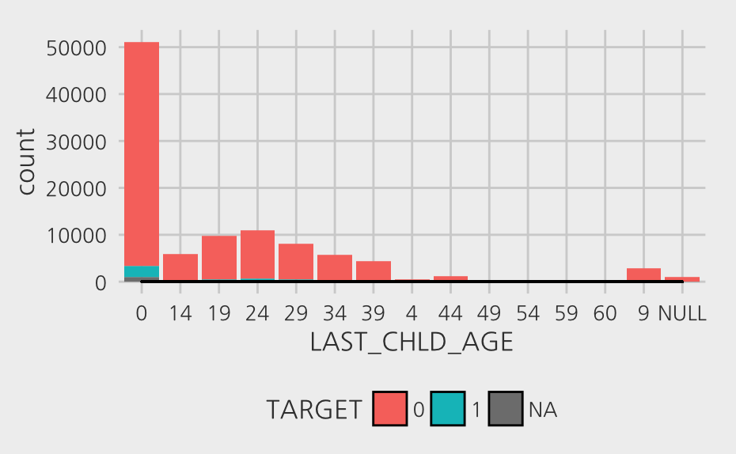

```r
full.data %>%
  ggplot(aes(LAST_CHLD_AGE, fill=TARGET)) +
  geom_bar() +
  geom_density(alpha=.5)
```

0인 (나이 또는 존재 자체를 를 알 수 없는) 데이터 수가 너무 많다.

```r
full.data$LAST_CHLD_AGE[is.na(full.data$LAST_CHLD_AGE)] <- 0
```

#### 5) PAYM_METD 납부방법 데이터 살펴보기

```r
summary(full.data$PAYM_METD)
```

```
          G     K     O     R
 2878  4625 33027 58076  3646
```

결측,비식별 " “데이터 2878개 약 3%

시각화해보면,

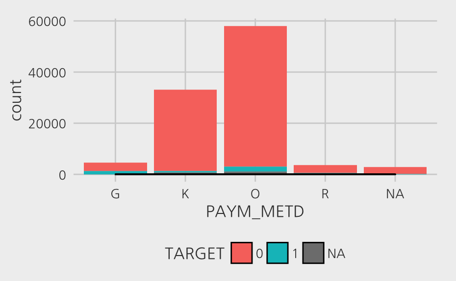

```r
full.data$PAYM_METD[full.data$PAYM_METD==""] <- NA
full.data %>%
  ggplot(aes(PAYM_METD, fill=TARGET)) +
  geom_bar() +
  geom_density(alpha=.5)
```

범주가 적으므로 MICE(다중대체법)로 예측하여 채워넣는다. 다음에 살펴볼 TEL_MBSP_GRAD(멤버쉽 등급 데이터)결측치와 같이 처리하도록 한다.

#### 6) TEL_MBSP_GRAD 멤버쉽 등급 데이터 살펴보기

```r
summary(full.data$TEL_MBSP_GRAD)
```

```
          E     Q     R     W
46989  4103 13913 20235 17012
```

46989개 데이터의 멤버쉽 등급을 알 수 없다. 전체 데이터의 약 45% 정도이다.

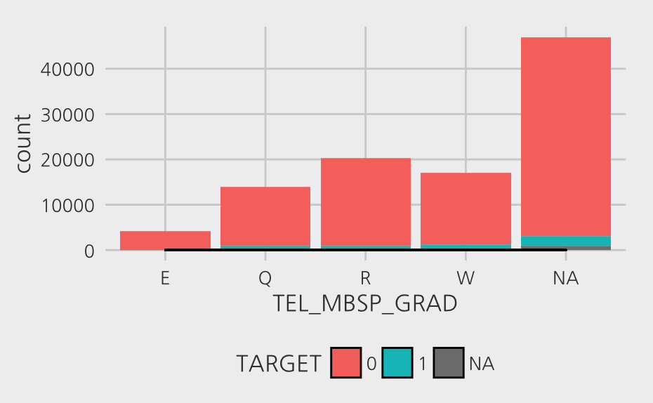

```r
full.data$TEL_MBSP_GRAD[full.data$TEL_MBSP_GRAD==""] <- NA
full.data %>%
  ggplot(aes(TEL_MBSP_GRAD, fill=TARGET)) +
  geom_bar() +
  geom_density(alpha=.5)
```

멤버쉽 등급은 전년도 누적 납부금액, 가입기간 및 연체 여부를 합산해 VIP, Gold, Silver,일반으로 구분된다.

ARPU(가입자매출), MON_TLFE_AMT(납부요금), CBPT_MBSP_YN(결합상품가입여부), TEL_CNTT_QTR(가입년월), CRMM_OVDU_AMT(당월연체금액), TLFE_UNPD_CNT(납부일미준수횟수), LT1Y_MXOD_AMT(년간최대연체금액) 변수들을 이용해 멤버쉽 등급을 예측하여 대체한다.

대체 방법으로 **MICE (multiple imputation) 다중대체법**을 사용한다.

#### # MICE(Multivariate Imputation) 다중대체법

: 시뮬레이션을 반복하여 누락된 데이터를 채워넣는 방법

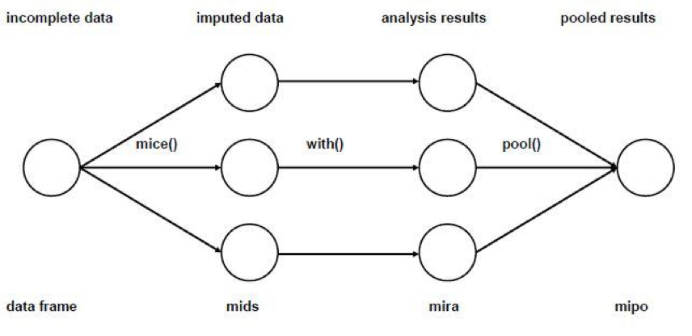

1. simulation을 통하여 누락된 자료를 채운 dataset을 3-5개 만든다.(default = 5)
2. 각각의 dataset에 대해 표준적인 통계방법을 적용하여 분석
3. 분석 결과를 하나의 결과로 통합한다.

#### TEL_MBSP_GRAD 멤버쉽 등급, PAYM_METD 납부방법 결측치 대체하기

```r
##### MICE (multiple imputation) #####
# install.packages("mice")
library(mice)
# 빈 factor 레벨 삭제하기
full.data$TEL_MBSP_GRAD <- as.character(full.data$TEL_MBSP_GRAD)
full.data$TEL_MBSP_GRAD <- as.factor(full.data$TEL_MBSP_GRAD)
full.data$PAYM_METD <- as.character(full.data$PAYM_METD)
full.data$PAYM_METD <- as.factor(full.data$PAYM_METD)
mice.col <- c("TEL_MBSP_GRAD","ARPU", "MON_TLFE_AMT", "CBPT_MBSP_YN", "TEL_CNTT_QTR", "CRMM_OVDU_AMT", "TLFE_UNPD_CNT", "LT1Y_MXOD_AMT", "PAYM_METD")
imp = mice(full.data[, mice.col],method = c("cart"),seed=1234)
full.data[, mice.col] <- complete(imp) # merge the imputed values into original data set
# 빈 factor레벨 지우기
full.data$PAYM_METD <- as.character(full.data$PAYM_METD)
full.data$PAYM_METD <- as.factor(full.data$PAYM_METD)
full.data$TEL_MBSP_GRAD <- as.character(full.data$TEL_MBSP_GRAD)
full.data$TEL_MBSP_GRAD <- as.factor(full.data$TEL_MBSP_GRAD)
```

### 금액 데이터 단위 1원으로 맞추기

- SCI 데이터 * 1000
- 한화생명 소득금액 데이터 * 10000

```r
# SCI 데이터 - 단위 : 1000원
full.data$TOT_LNIF_AMT <- (full.data$TOT_LNIF_AMT) * 1000
full.data$TOT_CLIF_AMT <- (full.data$TOT_CLIF_AMT) * 1000
full.data$BNK_LNIF_AMT <- (full.data$BNK_LNIF_AMT) * 1000
full.data$CPT_LNIF_AMT <- (full.data$CPT_LNIF_AMT) * 1000
full.data$CB_GUIF_AMT <- (full.data$CB_GUIF_AMT) * 1000
# 한화생명 소득금액 데이터 - 단위 : 10000원
full.data$CUST_JOB_INCM <- (full.data$CUST_JOB_INCM) * 10000
full.data$HSHD_INFR_INCM <- (full.data$HSHD_INFR_INCM) * 10000
# SKT데이터 단위는 1원
```

##### 금액 데이터 변환 작업

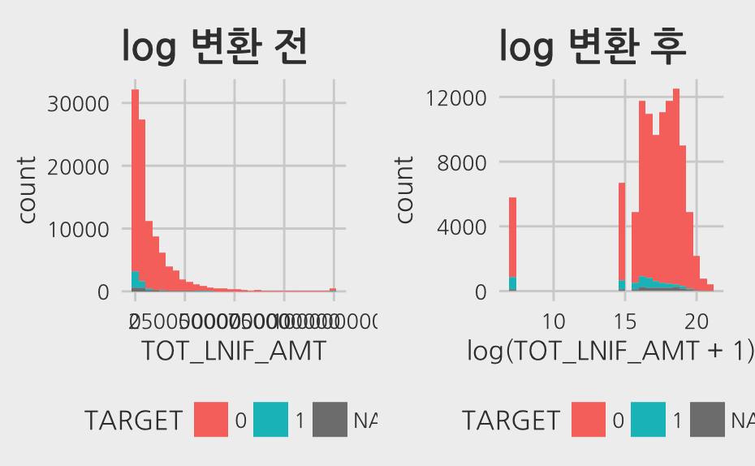

```r
library(gridExtra)
# TOT_LNIF_AMT 대출정보 현재 총 금액 로그변환
plot1 <- full.data %>% ggplot(aes(TOT_LNIF_AMT, fill=TARGET)) + geom_histogram(bins = 30) + ggtitle("log 변환 전")
plot2 <- full.data %>% ggplot(aes(log(TOT_LNIF_AMT + 1), fill=TARGET)) + geom_histogram(bins = 30) + ggtitle("log 변환 후")
grid.arrange(plot1, plot2,  nrow=1, ncol=2)
```

일부 금액 데이터를 히스토그램으로 시각화해 보면 왼쪽 그래프처럼 데이터가 한쪽으로 몰려있다.

정규화 하기 위해 log또는 sqrt변환을 해준다.

다른 변수도 마찬가지로 확인후 변환한다.

```r
# plot3 <- full.data %>% ggplot(aes(LT1Y_STLN_AMT, fill=TARGET)) + geom_histogram(bins = 30) + labs(title="변화 전 데이터")
# plot4 <- full.data %>% ggplot(aes(log(LT1Y_STLN_AMT + 1), fill=TARGET)) + geom_histogram(bins = 30) + labs(title="log변환 후")
# plot5 <- full.data %>% ggplot(aes(sqrt(LT1Y_STLN_AMT), fill=TARGET)) + geom_histogram(bins = 30) + labs(title="sqrt변환 후")
# grid.arrange(plot3, plot4, plot5 ,nrow=1, ncol=3)
#
# # 정규성 검정
# shapiro.test(sample(full.data$LT1Y_STLN_AMT,1000,replace = FALSE))
# shapiro.test(sample(log(full.data$LT1Y_STLN_AMT+1),1000,replace = FALSE))
# shapiro.test(sample(sqrt(full.data$LT1Y_STLN_AMT),1000,replace = FALSE))
```

```r
#######################################금액데이터 변환####################################
full.data$TOT_LNIF_AMT = log(full.data$TOT_LNIF_AMT+1)
full.data$TOT_CLIF_AMT = log(full.data$TOT_CLIF_AMT+1)
full.data$BNK_LNIF_AMT = log(full.data$BNK_LNIF_AMT+1)
full.data$CPT_LNIF_AMT = log(full.data$CPT_LNIF_AMT+1)
full.data$CB_GUIF_AMT =  log((full.data$CB_GUIF_AMT)+1)
full.data$TOT_CRLN_AMT = log((full.data$TOT_CRLN_AMT)+1)
full.data$TOT_REPY_AMT = log((full.data$TOT_REPY_AMT)+1)
full.data$STLN_REMN_AMT = log(full.data$STLN_REMN_AMT+1)
full.data$LT1Y_STLN_AMT = log(full.data$LT1Y_STLN_AMT+1)
full.data$FYCM_PAID_AMT = log(full.data$FYCM_PAID_AMT+1)
full.data$MON_TLFE_AMT =sqrt(full.data$MON_TLFE_AMT)
full.data$CRMM_OVDU_AMT = log(full.data$CRMM_OVDU_AMT+1)
full.data$LT1Y_MXOD_AMT = sqrt(full.data$LT1Y_MXOD_AMT)
full.data$GDINS_MON_PREM = log(full.data$GDINS_MON_PREM+1)
full.data$SVINS_MON_PREM = log(full.data$SVINS_MON_PREM+1)
full.data$MAX_MON_PREM = log(full.data$MAX_MON_PREM+1)
full.data$TOT_PREM = log(full.data$TOT_PREM+1)
full.data$FMLY_TOT_PREM = log(full.data$FMLY_TOT_PREM+1)
full.data$FMLY_GDINS_MNPREM = sqrt(full.data$FMLY_GDINS_MNPREM)
full.data$FMLY_SVINS_MNPREM = log(full.data$FMLY_SVINS_MNPREM+1)
full.data$MOBL_PRIN = sqrt(full.data$MOBL_PRIN)
```

### 3. 데이터 나누기 (train, test)

```r
# write.csv(full.data, file="full.data.csv",row.names = FALSE)
# reload.data <- read.csv("full.data.csv",header = T)
# full.data <- reload.data
data.df <- full.data[1:100233,]
test.df <- full.data[100234:102252,]
# data.df를 다시 train, test데이터로 나누기 (80:20 비율로)
parts <- createDataPartition(data.df$TARGET, p=0.8)
train.data <- data.df[parts$Resample1,]
dim(train.data)
```

```
[1] 80187    69
```

```r
test.data <- data.df[-parts$Resample1,]
dim(test.data)
```

```
[1] 20046    69
```

### 4. 변수 중요도 파악하기

#### 1) 병렬처리를 위한 Parallel패키지 사용하기

```r
# Parallel 셋팅
library(parallelMap)
library(parallel)
parallelStartSocket(cpus = detectCores())

# parallelStop()
```

필터 방법으로 모델링에 사용할 변수를 선택하기로 한다.

먼저 분산이 0에 가까운 변수를 찾아 제외한다.

(분산이 0에 가까운 변수는 서로 다른 관찰을 구분하는 데 별 소용이 없다. 따라서 데이터 모델링에서도 그리 유용하지 않다.)

#### 2) nearZeroVar() 함수를 사용해 분산이 0에 가까운 변수를 찾기

```r
# 분산이 0에 가까운 변수를 찾아 제외한다.
library(mlbench)
nearZeroVar(train.data)
```

```
 [1]  2 15 16 24 26 27 28 29 30 31 32 33 37 38 39 41 43 48 55 56 63 64 65
[24] 66 68 69
```

```r
mean.var <- train.data[,-nearZeroVar(train.data)]
# 69개의 변수 중 43개의 변수가 선택되었다.
names(mean.var)
```

```
 [1] "CUST_ID"           "BNK_LNIF_CNT"      "CPT_LNIF_CNT"
 [4] "SPART_LNIF_CNT"    "ECT_LNIF_CNT"      "TOT_LNIF_AMT"
 [7] "TOT_CLIF_AMT"      "BNK_LNIF_AMT"      "CPT_LNIF_AMT"
[10] "CRDT_OCCR_MDIF"    "SPTCT_OCCR_MDIF"   "CRDT_CARD_CNT"
[13] "CTCD_OCCR_MDIF"    "OCCP_NAME_G"       "CUST_JOB_INCM"
[16] "HSHD_INFR_INCM"    "ACTL_FMLY_NUM"     "CUST_FMLY_NUM"
[19] "LAST_CHLD_AGE"     "MATE_OCCP_NAME_G"  "CRDT_LOAN_CNT"
[22] "PREM_OVDU_RATE"    "LT1Y_PEOD_RATE"    "AVG_STLN_RATE"
[25] "GDINS_MON_PREM"    "FMLY_GDINS_MNPREM" "MAX_MON_PREM"
[28] "TOT_PREM"          "FMLY_TOT_PREM"     "CNTT_LAMT_CNT"
[31] "AUTR_FAIL_MCNT"    "FYCM_PAID_AMT"     "FMLY_CLAM_CNT"
[34] "FMLY_PLPY_CNT"     "AGE"               "SEX"
[37] "TEL_MBSP_GRAD"     "ARPU"              "MON_TLFE_AMT"
[40] "CBPT_MBSP_YN"      "MOBL_FATY_PRC"     "TEL_CNTT_QTR"
[43] "PAYM_METD"
```

#### 3) 랜덤포레스트 모델을 사용해 중요한 변수 찾기

## 3. 변수 중요도 평가

랜덤포레스트 모델은 변수의 중요도를 평가하고 모델링에 사용할 변수를 선택하는 데 사용할 수 있다.

변수 중요도는 변수가 정확도(Accuracy)와 노드 불순도(Node Impurity) 개선에 얼마만큼 기여하는지로 측정된다.

이렇게 구한 변수 중요도는 다른 모델에 사용할 변수를 선택하는 데 사용할 수 있다.

```r
# 위에서 필터링한 43개의 변수 중 중요할 것 같은 변수 30개를 넣어서 랜덤포레스트 모델로 돌려보기
col.pred <- c( "CTCD_OCCR_MDIF" ,"MATE_OCCP_NAME_G"  ,"PREM_OVDU_RATE","SPART_LNIF_CNT",
               "TOT_LNIF_AMT","TOT_CLIF_AMT","LT1Y_PEOD_RATE","TARGET","OCCP_NAME_G",
               "CUST_JOB_INCM","HSHD_INFR_INCM","GDINS_MON_PREM","FMLY_GDINS_MNPREM",
               "TOT_PREM","FMLY_TOT_PREM","MAX_MON_PREM","SPTCT_OCCR_MDIF","CRDT_CARD_CNT",
               "FMLY_PLPY_CNT","AGE","ARPU", "AUTR_FAIL_MCNT","FYCM_PAID_AMT", "MON_TLFE_AMT",
               "MOBL_FATY_PRC","TEL_CNTT_QTR","PAYM_METD","BNK_LNIF_AMT","CPT_LNIF_AMT","CRDT_OCCR_MDIF")
rf_fit2 <- randomForest(as.factor(TARGET) ~. , data = train.data[,col.pred] ,mtry = 8 , importance =TRUE)
```

```r
tmp <- importance(rf_fit2)
# tmp

varImpPlot(rf_fit2)
```

[output not shown]

```r
# 정확도 개선에 중요한 변수(MeanDecreaseAccuracy가 높은 변수) 9개 빼놓기 (TARGET포함 10개)
col.pred.9 <- c("PAYM_METD","CRDT_CARD_CNT","AGE","CRDT_OCCR_MDIF",
  "TOT_LNIF_AMT","SPTCT_OCCR_MDIF","FMLY_TOT_PREM","TOT_PREM", "CPT_LNIF_AMT","TARGET")

col.pred.9
```

TARGET이 연체하는 경우(1) , 상환하는 경우(0) 를 분류하여 예측하는 것이 목적이다. 그러므로 적절한 모델은 로지스틱 회귀분석, SVM, 의사결정나무, 랜덤포레스트 등이다. 이 중 랜덤 포레스트와 SVM모델을 사용하기로 했다. 둘 중 결과가 좋은 모델을 선택하여 튜닝하고, 성능을 높이는 과정을 반복한다.

#### # 랜덤포레스트 모델

주어진 데이터로부터 여러개의 모델을 학습한 다음, 예측 시 여러 모델의 예측 결과들을 종합해 사용하여 정확도를 높이는 앙상블 기법

1. Bagging으로 나온 여러 sub-data로 Decision tree 모델을 만듦
2. 각 결정트리로부터 얻어진 결과를 평균, 확률등 종합하여 최종 결과를 도출
3. 장점
- Random sampled sub-data로 모델간 correlation 방지
- Bagging이 결합되면서 Overfitting 문제를 모델 자체적으로 해결할 수 있음

### 5. 랜덤포레스트 모델 사용하기

#### 1) 모델 적용, 튜닝하기

```r
library(mlr)

train.data$TARGET <- as.factor(train.data$TARGET)
test.data$TARGET <- as.factor(test.data$TARGET)

# Task 생성
traintask <- makeClassifTask(data = train.data[,-1], target = "TARGET")
testtask <- makeClassifTask(data = test.data[,-1], target = "TARGET")

getParamSet("classif.randomForest")

# learner 생성
rf.lrn <- makeLearner("classif.randomForest", predict.type = "response", par.vals = list(ntree = 200, mtry = 3))
```

```r
#set tunable parameters
#grid search to find hyperparameters
# 모델 Tuning
getParamSet(rf.lrn)
rf.lrn$par.vals <- list(ntree = 200L,
                        importance=TRUE,
                        cutoff=c(0.80,0.20)
)

# parameter space 지정
params <- makeParamSet(
  makeIntegerParam("mtry",
                   lower = 4,
                   upper = 9),
  makeIntegerParam("nodesize",
                   lower = 30,
                   upper = 50)
)

# Validation strategy 지정
rdesc <- makeResampleDesc("CV",
                          iters=5L)

# Optimization technique 지정
ctrl <- makeTuneControlRandom(maxit = 5L)
```

```r
tune <- tuneParams(learner = rf.lrn
                   ,task = traintask
                   ,resampling = rdesc
                   ,measures = list(acc)
                   ,par.set = params
                   ,control = ctrl
                   ,show.info = T)
# 결과
# [Tune] Started tuning learner classif.randomForest for parameter set:
#             Type len Def   Constr Req Tunable Trafo
# mtry     integer   -   -  2 to 10   -    TRUE     -
# nodesize integer   -   - 10 to 50   -    TRUE     -
# With control class: TuneControlRandom
# Imputation value: -0
# Exporting objects to slaves for mode socket: .mlr.slave.options
# Mapping in parallel: mode = socket; cpus = 4; elements = 5.
# [Tune] Result: mtry=5; nodesize=44 : acc.test.mean=0.96

# [Tune] Started tuning learner classif.randomForest for parameter set:
#             Type len Def   Constr Req Tunable Trafo
# mtry     integer   -   -   4 to 9   -    TRUE     -
# nodesize integer   -   - 30 to 50   -    TRUE     -
# With control class: TuneControlRandom
# Imputation value: -0
# Exporting objects to slaves for mode socket: .mlr.slave.options
# Mapping in parallel: mode = socket; cpus = 4; elements = 5.
# [Tune] Result: mtry=4; nodesize=41 : acc.test.mean=0.958
```

```r
tune
```

```r
#using hyperparameters for modeling
rf.tree <- setHyperPars(rf.lrn, par.vals = tune$x)

#train a model
rforest <- train(rf.tree, traintask)
getLearnerModel(rforest)
```

#### 2) 튜닝한 모델로 예측하기

```r
#make predictions
rfmodel <- predict(rforest, testtask)

rfmodel2<- data.frame(rfmodel$data)

data.frame(rfmodel)

# Parallelization 종료
# parallelStop()
```

#### 3) 예측한 결과 분석하기

```r
tt <- confusionMatrix(data = rfmodel2$response, rfmodel2$truth, positive = "1")
tt

TP <- tt$table[4]
TN <- tt$table[1]
FP <- tt$table[2]
FN <- tt$table[3]

recall <- TP/(TP+FN)
pre <- TP / (TP+FP)
f <- 2*(pre*recall)/(pre+recall)
f
```

[output not shown]

#### 1) 모델 적용 전에 데이터 스케일링, 센터링 작업

```r
glimpse(train.data[,col.pred.9])
```

```r
col.scale <- c("CRDT_CARD_CNT","CRDT_OCCR_MDIF","TOT_LNIF_AMT","SPTCT_OCCR_MDIF",                       "FMLY_TOT_PREM","TOT_PREM", "CPT_LNIF_AMT")
scale.df <- train.data

scale.df[,col.scale] <- data.frame(scale(scale.df[,col.scale],scale = TRUE, center = TRUE))
scaled.train.data <- scale.df[,col.pred.9]
glimpse(scaled.train.data)
```

test 데이터도 마찬가지로 적용

```r
scale.test.df <- test.data

scale.test.df[,col.scale] <- data.frame(scale(scale.test.df[,col.scale],scale = TRUE, center = TRUE))
scaled.test.data <- scale.test.df[,col.pred.9]
glimpse(scaled.test.data)
```

#### 2) SVM 모델 적용 후 결과 분석

```r
library(mlr)

traintask <- makeClassifTask(data = scaled.train.data, target = "TARGET")
testtask <- makeClassifTask(data = scaled.test.data, target = "TARGET")

#load svm
getParamSet("classif.ksvm")
ksvm <- makeLearner("classif.ksvm", predict.type = "response")

#Set parameters
pssvm <- makeParamSet(
makeDiscreteParam("C", values = 2^(-2:2)), # cost
makeDiscreteParam("sigma", values = 2^(-2:2)) # Kernel
)

#specify search function
ctrl <- makeTuneControlGrid()

#tune model
res <- tuneParams(ksvm, task = traintask, resampling = rdesc, par.set = pssvm, control = ctrl,measures = acc)

# > res$x
# $C
# [1] 0.25
#
# $sigma
# [1] 4

#CV accuracy
res$y
acc.test.mean


#set the model with best params
t.svm <- setHyperPars(ksvm, par.vals = res$x)

#train
par.svm <- train(ksvm, traintask)

#test
predict.svm <- predict(par.svm, testtask)

predict.data <- data.frame(predict.svm$data)

svm.con <- confusionMatrix(data = predict.data$response, predict.data$truth, positive = "1")

svm.con
```

[output not shown]

#### 7. 튜닝한 랜덤포레스트로 최종 예측 후 제출

```r
test.df$LAST_CHLD_AGE[test.df$LAST_CHLD_AGE == NA] <- 0

rfmodel1 <- predict(rforest, newdata = test.df[,-1])

rfmodel2<- data.frame(rfmodel1$data)

write.csv(rfmodel2, "submit.csv")
```

#### 8. 결과

제출결과 본선진출 X

진출팀 F1 score는 0.4 ~ 0.5

고려해봐야할 것

- up sampling, down sampling을 통한 데이터 Balance맞추기
- Stacking 시도